# Ewing EWS-FLI1 knockdown expression data

## Setting up the environment

These are packages you will need for this notebook. For exact versions used, please refer to the session info at the bottom of this notebook.

```r
##########################################################################################
library('tidyverse')
library('ggplot2')
library('RColorBrewer')
library('tximport')
library('GenomicFeatures')
library('ggrepel')
library('org.Hs.eg.db')
```

I want to set a base directory that we can use as a link to the directory where we will do most of the work. I use two directories here because the Workspace is what is pushed to GitHub and contains scripts and plot files, but the Repository is where more of the big data is stored that does not get pushed.

```r
##########################################################################################
generalDatasets = 'C:/Users/chughes/Documents/bccrc/projectsRepository/generalDatasets'
baseWorkspace = 'C:/Users/chughes/Documents/bccrc/projectsWorkspace/sorensenLab/relatedToDlg2'
baseRepository = 'C:/Users/chughes/Documents/bccrc/projectsRepository/sorensenLab/relatedToDlg2'
#generalDatasets = 'C:/Users/chris/OneDrive/Documents/bccrc/projectsRepository/generalDatasets'
#baseWorkspace = 'C:/Users/chris/OneDrive/Documents/bccrc/projectsWorkspace/sorensenLab/relatedToYbx1'
#baseRepository = 'C:/Users/chris/OneDrive/Documents/bccrc/projectsRepository/sorensenLab/relatedToYbx1'
```

## Data processing

The first thing to do is to make a sample annotation table.

```r
##########################################################################################
samples = tibble('tissue' = c('neg.1','neg.2','ewsr1.1','ewsr1.2','fli1.1','fli1.2'),
                 'cellLine' = c('TC32','TC32','TC32','TC32','TC32','TC32'),
                 'sample' = c('SRR6035978','SRR6035979','SRR6035980','SRR6035981','SRR6035982','SRR6035983'))
```

Next we point at our quant files.

```r
##########################################################################################
quantFiles = file.path(paste(baseRepository, '/sequencing20211104_ef1MetabolismSenPmid29873416/quants', sep = ''), samples$sample, 'quant.sf')
names(quantFiles) = samples$sample
all(file.exists(quantFiles))
```

```
[1] TRUE
```

Build the transcriptome index.

```r
##########################################################################################
txdb = makeTxDbFromGFF('D:/databases/projectEwsDlg2/baseGenomeFiles/genome.gtf')
```

```
Import genomic features from the file as a GRanges object ... OK
Prepare the 'metadata' data frame ... OK
Make the TxDb object ... Warning in .get_cds_IDX(mcols0$type, mcols0$phase) :
  The "phase" metadata column contains non-NA values for features of type stop_codon. This information was ignored.
OK
```

```r
k = keys(txdb, keytype = "TXNAME")
tx2gene = select(txdb, k, c("GENEID", "TXSTART", "TXEND"), "TXNAME")
```

Read the transcript data.

```r
##########################################################################################
txi = tximport(quantFiles, type = 'salmon', tx2gene = tx2gene)
```

```
reading in files with read_tsv
1 2 3 4 5 6
summarizing abundance
summarizing counts
summarizing length
```

```r
names(txi)
```

```
[1] "abundance"           "counts"              "length"              "countsFromAbundance"
```

```r
txiCounts = tibble(as.data.frame(txi$abundance)) %>%
  dplyr::mutate('ENSEMBL' = sub('(.*)\\.[0-9]+$', '\\1', row.names(txi$counts)))
geneSymbols = select(org.Hs.eg.db, txiCounts$ENSEMBL, c('ENSEMBL','SYMBOL'), 'ENSEMBL')
txiAnnotated = txiCounts %>%
  dplyr::left_join(geneSymbols) %>%
  dplyr::rename(symbol = SYMBOL, gene = ENSEMBL)
saveRDS(txiAnnotated, paste(baseRepository,'/sequencing20211104_ef1MetabolismSenPmid29873416/dataset_countDataFromSalmon.rds', sep = ''))
write.table(txiAnnotated, paste(baseRepository,'/sequencing20211104_ef1MetabolismSenPmid29873416/dataset_countDataFromSalmon.tsv', sep = ''),
            col.names = TRUE, row.names = FALSE, quote = FALSE, sep = '\t')
```

Make a plot of these data.

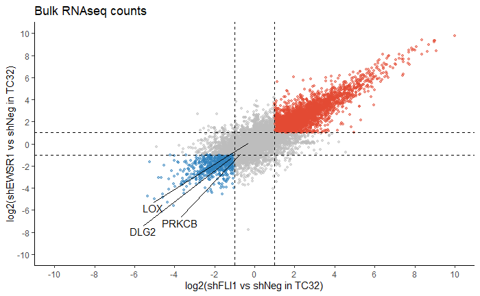

```r
##########################################################################################
rna = readRDS(paste(baseRepository,'/sequencing20211104_ef1MetabolismSenPmid29873416/dataset_countDataFromSalmon.rds', sep = ''))
rna$meanNeg = rowMeans(rna[,1:2], na.rm = TRUE)
rna$meanEws = rowMeans(rna[,3:4], na.rm = TRUE)
rna$meanFli = rowMeans(rna[,5:6], na.rm = TRUE)
rna$log2Ews = log2(rna$meanEws) - log2(rna$meanNeg)
rna$log2Fli = log2(rna$meanFli) - log2(rna$meanNeg)
rna = subset(rna, !is.na(rna$log2Ews) & !is.na(rna$log2Fli) & !is.infinite(rna$log2Ews) & !is.infinite(rna$log2Fli))

###
targetGenes = c('LOX','DLG2','PRKCB')
rna$pText = ifelse(rna$symbol %in% targetGenes, rna$symbol, '')
rna$pColors = ifelse(rna$log2Ews <= -1 & rna$log2Fli <= -1, brewer.pal(3,'Blues')[3],
                            ifelse(rna$log2Ews >= 1 & rna$log2Fli >= 1, brewer.pal(3,'OrRd')[3],
                                    brewer.pal(3,'Greys')[2]))
ggplot(rna, aes(log2Ews, log2Fli)) +
  geom_point(size = 1, color = rna$pColors, alpha = 0.5) +
  geom_text_repel(label = rna$pText, max.overlaps = 15000, nudge_y = -6, nudge_x = -4) +
  labs(x = 'log2(shFLI1 vs shNeg in TC32)', y = 'log2(shEWSR1 vs shNeg in TC32)', title = 'Bulk RNAseq counts') +
  geom_vline(xintercept = c(-1,1), linetype = 'dashed') +
  geom_hline(yintercept = c(-1,1), linetype = 'dashed') +
  scale_y_continuous(limits = c(-10,10), breaks = seq(-10,10,2)) +
  scale_x_continuous(limits = c(-10,10), breaks = seq(-10,10,2)) +
  theme_classic()
ggsave(paste(baseRepository, '/sequencing20211104_ef1MetabolismSenPmid29873416/scatter_allTargetsSalmonRnaExpressionShEwsfli1Tc32.pdf', sep = ''),
      height = 2, width = 2, useDingbats = FALSE)
```

This data looks a bit odd compared to the others. Maybe their shRNA is not as good?

[session information not shown]